# *Macrocystis pyrifera* — Study Population Maps

IMAS Honours 2026 — Harry Silke

2026-11-01

## What changed from the previous version

Two things, and nothing else. The geometry, the site list, the insets and the composition are untouched.

**The colours are now the validated cluster palette**, the same five used on the genetic-distance line, in the crossing diagram and in Figure 2. Before this, the map and the distance line sitting beside it on the same slide used two different colour systems: South-east Tas was teal on one and dark grey on the other, South Tas was green on one and blue on the other. Only East Tas happened to agree. The palette was checked for colour-vision deficiency: worst normal-vision delta-E 19.0, worst dichromat 14.2, worst contrast 3.40:1. South-east Tas is deliberately the neutral dark grey, because it is the one population in every cross.

**The names can be either form.** `USE_SHORT_NAMES` at the top switches the legend between the short regional names used in the talk and the full cluster names the thesis should keep. The colours and the site labels are the same either way, so both versions stay in step.

```r
library(ggplot2)
library(sf)
library(rnaturalearth)
library(rnaturalearthdata)
library(ggrepel)
library(cowplot)
```

## Shared data

```r
aus_states <- ne_countries(country = "Australia", scale = "medium",
                           returnclass = "sf")

# TRUE for the talk, FALSE for the thesis.
USE_SHORT_NAMES <- TRUE

# Validated cluster palette, shared with the distance line and Figure 2.
# Order is the one used on the distance line: the focal population first,
# then the close partner, then the three medium ones.
pal <- c("#333333", "#008CDF", "#D76F0B", "#A74371", "#0C33A0")

pop_full <- c("Frederick Henry\n& Storm Bays",
              "Actaeon Island\n& Southport",
              "St Helens Point\n& Falmouth",
              "East Coast\nVictoria",
              "North Coast\nTasmania")

pop_short <- c("SE Tas", "S Tas", "E Tas", "E Vic", "N Tas")

pop_labels  <- if (USE_SHORT_NAMES) pop_short else pop_full
pop_colours <- setNames(pal, pop_labels)
pop_levels  <- pop_labels

# Publication-style base theme — B&W
base_theme <- theme_bw(base_size = 10) +
  theme(
    plot.title        = element_text(face = "bold", size = 10, colour = "black"),
    plot.subtitle     = element_text(size = 8, colour = "grey30"),
    plot.caption      = element_text(size = 7, colour = "grey50", hjust = 0),
    panel.background  = element_rect(fill = "white", colour = "black"),
    panel.grid.major  = element_line(colour = "grey90", linewidth = 0.3),
    panel.grid.minor  = element_blank(),
    plot.background   = element_rect(fill = "white", colour = NA),
    plot.margin       = margin(5, 5, 5, 5),
    legend.background = element_rect(fill = "white", colour = "grey70",
                                     linewidth = 0.3),
    legend.title      = element_text(size = 8, face = "bold"),
    legend.text       = element_text(size = 7),
    legend.key.size   = unit(0.4, "cm"),
    legend.position   = "top",
    legend.direction  = "horizontal",
    axis.title        = element_text(size = 8),
    axis.text         = element_text(size = 7)
  )
```

## Site data

Only the 11 sites that contributed gametophytes to the crossing experiment. Sites sampled in the population genomic survey but not used here have been dropped, including Cod Bay, George Rocks and Ben’s Creek, which belong to a separate CSIRO cluster and were previously shown in the St Helens colour in error.

```r
# Six individuals per cluster, drawn from the site codes below.
#
#   SE Tas, Frederick Henry & Storm Bays  LSI_4, LSI_5, LSI_6, LSI_7, LSI_20, IOC_9
#   S Tas,  Actaeon Island & Southport    ACT_4, ACT_5, ACT_17, FSH_3, FSH_7, FSH_16
#   E Tas,  St Helens Point & Falmouth    SHL_4, SHL_5, SHL_17, BBB_13, BBB_14, BBB_17
#   E Vic,  East Coast Victoria           DIP_1, DIP_3, DIP_7, SDP_13, SDP_15, PHK_4
#   N Tas,  North Coast Tasmania          ULV_2, ULV_3, ULV_15, DEV_10, DEV_11, DEV_16

sites_all <- data.frame(
  site = c("ACT", "FSH",
           "LSI", "IOC",
           "SHL", "BBB",
           "ULV", "DEV",
           "DIP", "SDP", "PHK"),
  location = c(
    "Actaeon Island", "Fishers Point",
    "Little Spectacle Is.", "Isle of Caves",
    "Shelly Point", "Beerbarrel Beach",
    "Black Jack Rock", "Devonport",
    "Petrel Point", "Sandpatch Point", "Stable Bay"
  ),
  lon = c(
    146.9943, 146.9266,
    147.5995, 147.6505,
    148.2785, 148.3599,
    146.1649, 146.3702,
    149.4323, 149.6060, 149.2816
  ),
  lat = c(
    -43.5258, -43.5742,
    -42.8674, -42.9083,
    -41.4353, -41.2835,
    -41.1361, -41.1670,
    -37.7809, -37.7096, -37.7979
  ),
  # index into pop_labels, so the labels can be switched without touching this
  pop_key = c(2, 2,
              1, 1,
              3, 3,
              5, 5,
              4, 4, 4),
  n_individuals = c(3, 3, 5, 1, 3, 3, 3, 3, 3, 2, 1)
)
sites_all$population <- factor(pop_labels[sites_all$pop_key],
                               levels = pop_levels)

# individuals per cluster, as a check
aggregate(n_individuals ~ population, sites_all, sum)
```

```
##   population n_individuals
## 1     SE Tas             6
## 2      S Tas             6
## 3      E Tas             6
## 4      E Vic             6
## 5      N Tas             6
```

## Main map

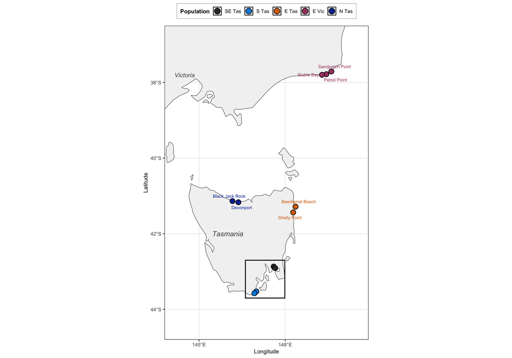

```r
# Inset box coordinates — SE Tasmania clusters.
# coord_sf holds equal ground distances, so a square panel needs the
# longitude span widened by 1/cos(latitude): at ~43.2 S that is a factor of
# about 1.37. Computed rather than hard-coded so it stays square if the
# extent is changed.
inset_ylim   <- c(-43.7, -42.7)
inset_ymid   <- mean(inset_ylim)
lat_span     <- diff(inset_ylim)
lon_span     <- lat_span / cos(inset_ymid * pi / 180)
inset_xmid   <- 147.30
inset_xlim   <- inset_xmid + c(-1, 1) * lon_span / 2

# Numeric graticule breaks. coord_sf passes these to sf::st_graticule(),
# which needs actual values, not a breaks function.
inset_xbreaks <- seq(ceiling(inset_xlim[1] * 2) / 2,
                     floor(inset_xlim[2] * 2) / 2, by = 0.5)
inset_ybreaks <- seq(ceiling(inset_ylim[1] * 2) / 2,
                     floor(inset_ylim[2] * 2) / 2, by = 0.5)

# Main map extent
xlim_main <- c(143.8, 150.9)
ylim_main <- c(-44.8, -36.5)

p_main <- ggplot() +
  geom_sf(data = aus_states,
          fill = "grey95", colour = "grey40", linewidth = 0.3) +
  coord_sf(xlim = xlim_main, ylim = ylim_main, expand = FALSE) +
  geom_point(
    data  = sites_all,
    aes(x = lon, y = lat, fill = population),
    shape = 21, size = 3, stroke = 0.6, colour = "black"
  ) +
  # Labels for non-clustered sites only (SE TAS cluster is in the inset)
  geom_text_repel(
    data  = subset(sites_all, lat > -42.6),
    aes(x = lon, y = lat, label = location, colour = population),
    size          = 2.2,
    lineheight    = 0.85,
    box.padding   = unit(0.25, "lines"),
    point.padding = unit(0.25, "lines"),
    segment.size  = 0.3,
    max.overlaps  = 25,
    seed          = 42,
    show.legend   = FALSE
  ) +
  scale_fill_manual(values = pop_colours, name = "Population") +
  scale_colour_manual(values = pop_colours) +
  # Inset box outline
  annotate("rect",
           xmin = inset_xlim[1], xmax = inset_xlim[2],
           ymin = inset_ylim[1], ymax = inset_ylim[2],
           fill = NA, colour = "black", linewidth = 0.6) +
  # State labels
  annotate("text", x = 146.0, y = -42.0, label = "Tasmania",
           fontface = "italic", colour = "grey30", size = 3.5) +
  annotate("text", x = 144.5, y = -37.8, label = "Victoria",
           fontface = "italic", colour = "grey30", size = 3.0) +
  annotate("text", x = 139.5, y = -36.8, label = "South Australia",
           fontface = "italic", colour = "grey30", size = 3.0) +
  scale_x_continuous(name = "Longitude",
                     breaks = seq(139, 151, 3),
                     labels = function(x) paste0(x, "°E")) +
  scale_y_continuous(name = "Latitude",
                     breaks = seq(-44, -37, 2),
                     labels = function(y) paste0(abs(y), "°S")) +
  base_theme +
  guides(fill = guide_legend(override.aes = list(size = 3.5),
                             nrow = if (USE_SHORT_NAMES) 1 else 2),
         colour = "none")

p_main
```

## Inset map — SE Tasmania cluster

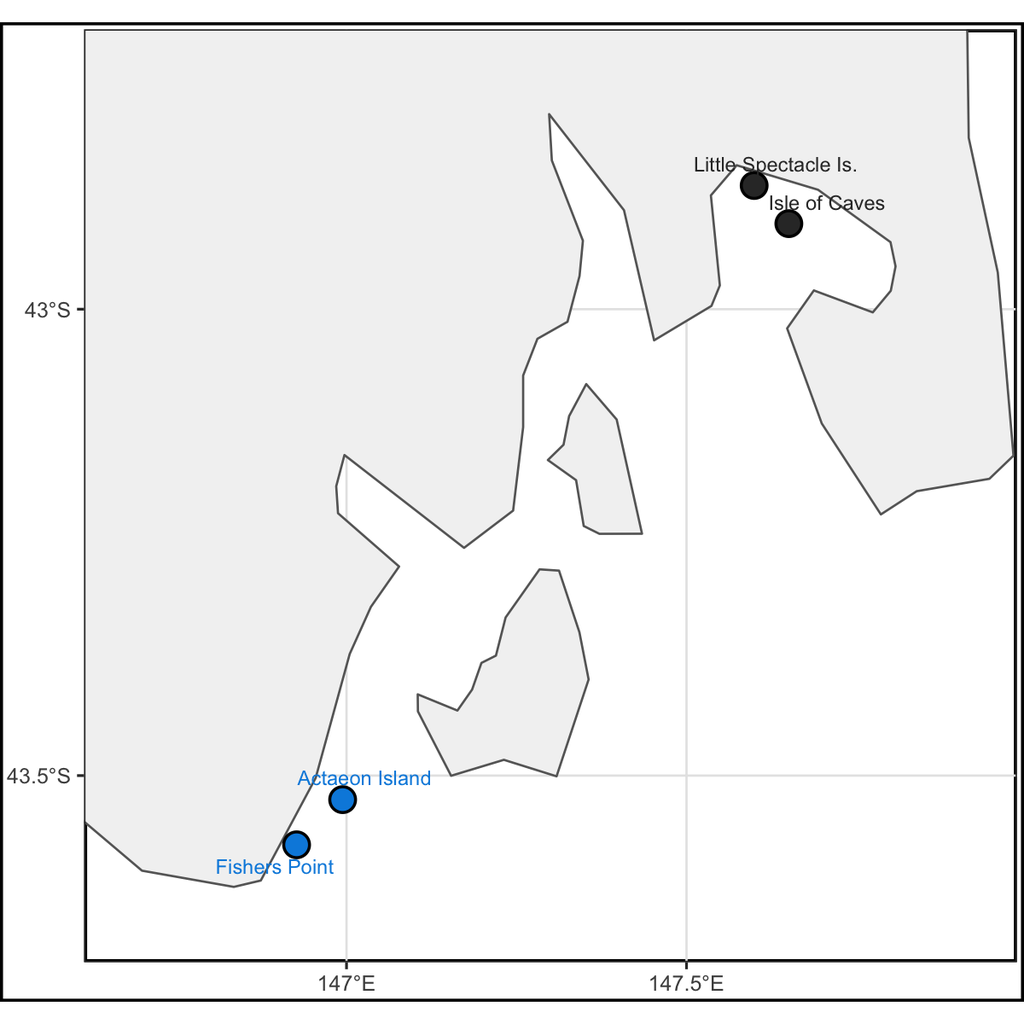

```r
# rendered square: extent is square and the chunk dimensions match

se_tas <- subset(sites_all, lat <= -42.6)

p_inset <- ggplot() +
  geom_sf(data = aus_states,
          fill = "grey95", colour = "grey40", linewidth = 0.3) +
  coord_sf(xlim = inset_xlim, ylim = inset_ylim, expand = FALSE) +
  geom_point(
    data  = se_tas,
    aes(x = lon, y = lat, fill = population),
    shape = 21, size = 3, stroke = 0.6, colour = "black"
  ) +
  geom_text_repel(
    data  = se_tas,
    aes(x = lon, y = lat, label = location, colour = population),
    size          = 2.0,
    lineheight    = 0.85,
    box.padding   = unit(0.2, "lines"),
    point.padding = unit(0.2, "lines"),
    segment.size  = 0.3,
    max.overlaps  = 30,
    seed          = 42,
    show.legend   = FALSE
  ) +
  scale_fill_manual(values = pop_colours) +
  scale_colour_manual(values = pop_colours) +
  scale_x_continuous(name = NULL,
                     breaks = inset_xbreaks,
                     labels = function(x) paste0(x, "°E")) +
  scale_y_continuous(name = NULL,
                     breaks = inset_ybreaks,
                     labels = function(y) paste0(abs(y), "°S")) +
  theme_bw(base_size = 8) +
  theme(
    panel.background = element_rect(fill = "white", colour = "black",
                                    linewidth = 0.8),
    panel.grid.major = element_line(colour = "grey90", linewidth = 0.3),
    panel.grid.minor = element_blank(),
    plot.background  = element_rect(fill = "white", colour = "black",
                                    linewidth = 0.8),
    axis.text        = element_text(size = 6),
    legend.position  = "none",
    plot.margin      = margin(2, 2, 2, 2)
  )

p_inset
```

## Locator inset — whole of Australia

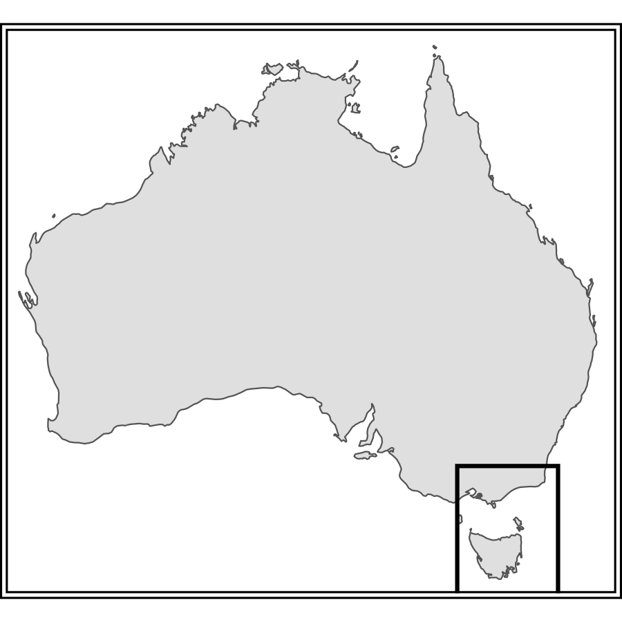

```r
p_locator <- ggplot() +
  geom_sf(data = aus_states,
          fill = "grey90", colour = "grey40", linewidth = 0.25) +
  annotate("rect",
           xmin = xlim_main[1], xmax = xlim_main[2],
           ymin = ylim_main[1], ymax = ylim_main[2],
           fill = NA, colour = "black", linewidth = 0.7) +
  coord_sf(xlim = c(112, 155), ylim = c(-44.5, -9), expand = FALSE) +
  theme_void() +
  theme(
    panel.background = element_rect(fill = "white", colour = "black",
                                    linewidth = 0.7),
    plot.background  = element_rect(fill = "white", colour = "black",
                                    linewidth = 0.7),
    plot.margin      = margin(2, 2, 2, 2)
  )

p_locator
```

## Combined figure with insets

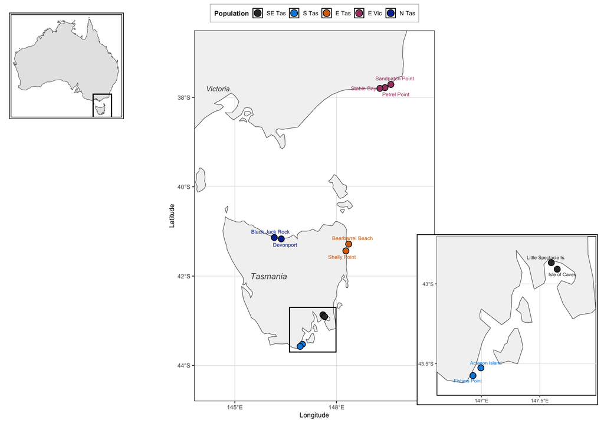

```r
fig_w <- 10; fig_h <- 7
inset_side   <- 3.0                    # SE Tasmania detail, inches
locator_side <- 1.9                    # Australia locator, inches

combined <- ggdraw(p_main) +
  draw_plot(
    p_inset,
    x = 0.69, y = 0.03,
    width  = inset_side / fig_w,
    height = inset_side / fig_h
  ) +
  draw_plot(
    p_locator,
    x = 0.015, y = 1 - 0.02 - locator_side / fig_h,
    width  = locator_side / fig_w,
    height = locator_side / fig_h
  )
combined
```

## Save outputs

```r
out <- if (USE_SHORT_NAMES) "kelp_map_talk.png" else "kelp_map_thesis.png"

ggsave(out, plot = combined, width = 10, height = 7, dpi = 300, bg = "white")
```

## Naming note

Three naming systems are now in play. State the mapping wherever you cite the CSIRO work for the cluster delineation.

| Talk | Thesis | CSIRO project update | Colour |
| --- | --- | --- | --- |
| SE Tas | Frederick Henry & Storm Bays | Frederick Henry & Storm Bays | `#333333` |
| S Tas | Actaeon Island & Southport | Actaeon Island, Sisters & Recherche Bays | `#008CDF` |
| E Tas | St Helens Point & Falmouth | St Helens & Shelly Points | `#D76F0B` |
| E Vic | East Coast Victoria | Wilderness Coast | `#A74371` |
| N Tas | North Coast Tasmania | Mersey & Leven river mouths | `#0C33A0` |